# Analysis of the Change of Ozone Concentration

Chapter 5 Report Exercise – Data Visullization

Ting Tan (22-108-534)

2025-06-08

## 1 Introduction

Ground-level ozone has significant impacts on both the environment and human health. While ozone in the upper atmosphere protects life by absorbing harmful ultraviolet (UV) radiation, elevated concentrations at ground level contribute to air pollution, causing respiratory issues and other health problems. Understanding ozone trends and the factors influencing its formation is essential for effective air quality management and public health protection.

Ozone levels vary over time, typically peaking in warmer months due to increased sunlight and temperature, which enhance photochemical reactions. Key influencing factors include temperature, solar radiation, wind speed, and the presence of pollutants such as nitrogen oxides (NOₓ) and volatile organic compounds (VOCs), especially in urban areas.

## 2 Research Question

- **How does solar radiation, wind and temperature affect the concentration of ground-level ozone?**

## 3 Available data

This analysis uses the airquality dataset in R, which contains 153 daily observations recorded in New York from May to September 1973. The data includes:

- Ozone (ppb) – Measured between 1–3 PM at Roosevelt Island
- Solar Radiation (lang) – Recorded 8–12 AM at Central Park
- Wind Speed (mph) – Morning average at LaGuardia Airport
- Temperature (°F) – Daily maximum at LaGuardia Airport
- Month and Day

## 4 Missing Value Handling

Out of 153 observations, 42 contain missing values in Ozone and Solar.R, mostly occurring in June (See Figure 1a). These incomplete records are excluded from the analysis to ensure data quality.

Figure 1b shows that ozone concentrations fluctuate notably during midsummer, with sharp, short-term spikes. The missing data in June limits full interpretation of trends during that period.

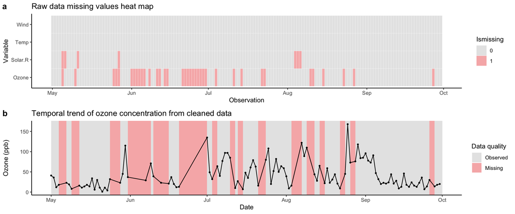

Figure 1: (a) Missing value distribution of all variables in the airquality dataset; (b) Temporal trend of Ozone concentration after data cleaning (i.e., removing all observations containing missing values).

## 5 Temporal Variation Analysis

To explore how ozone levels vary over time, we first compare their trends with those of solar radiation, wind speed, and temperature.

- Temperature shows a similar trend to ozone, suggesting a positive relationship.
- Wind Speed appears negatively related—higher ozone levels tend to occur on calmer days.
- Solar Radiation does not show a clear pattern in relation to ozone levels.

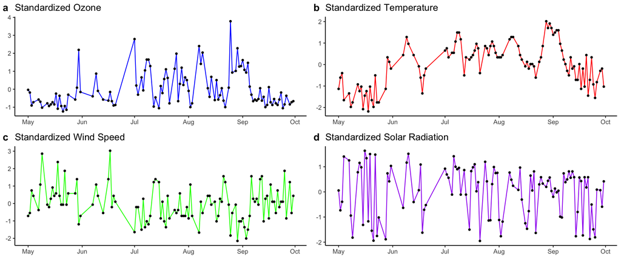

Figure 2: Temporal variations of standardized Ozone, Temperature, Wind Speed, and Solar Radiation, plotted separately.

## 6 Regression Analysis

These findings highlight the roles of temperature and wind in shaping urban ozone pollution. Such insights are valuable for informing air quality policies, especially in cities where temperature and wind patterns can exacerbate pollution episodes.

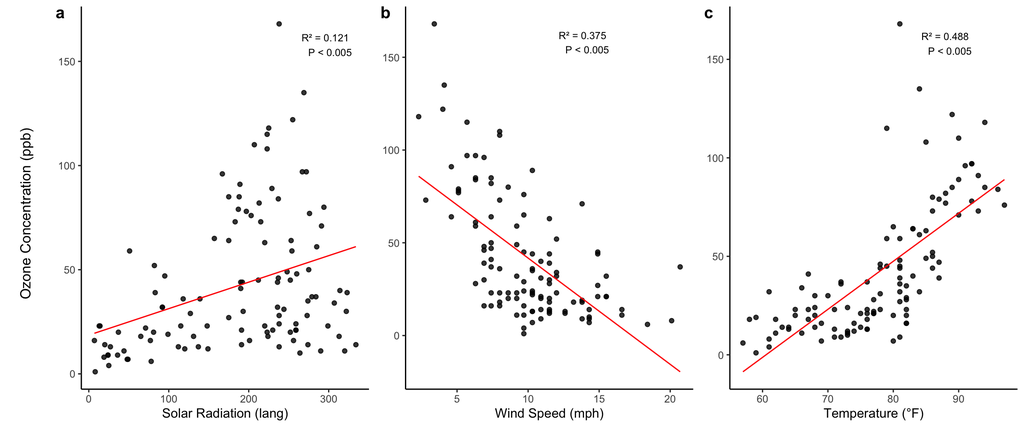

Figure 3: Regression analysis of Ozone concentration with environmental variables. (a) shows Solar Radiation, (b) shows Wind Speed, and (c) shows Temperature. Each plot includes the regression line with R² and p-value annotations.

## 7 Conclusion

Ozone levels in New York during summer 1973 were most strongly influenced by temperature and wind speed. Higher temperatures were linked to increased ozone, while stronger winds reduced it. Solar radiation showed a weaker effect. These findings highlight the need to consider weather conditions in managing urban air quality.